# Skilaverkefni tímaraðir h24

Hui

## Inngangur

Skilið lausn að verkefninu stafrænt fyrir kl.23:59 föstudaginn 16. nóvember með því að hlaða inn tveimur skrám. Ein skráin skal vera .Rmd skrá, sem inniheldur texta og R-kóða með lausnum að verkefninu. Hin skráin er .html skráin sem fæst með því að keyra .Rmd skrána með skipuninni ‘Knit to HTML’ og sýnir, auk texta og R-kóða, útkomuna úr kóðanum.

Verkefnin skulu vera snyrtilega sett fram og með skýringum. Vinnið saman í hópum.

Við lausn verkefnisins er gott að hafa þriðju skrána til að prófa keyrslur og sjá gildi breyta sem skilgreindar eru í kóðanum. Sú skrá er R-Script skrá með endinguna ‘.R’. Hægt er að keyra eina línu í einu í R-skránni með því að ljóma línuna og ýta á Ctrl+Enter.

Til að geta lesið íslenska stafi í .Rmd/.R-skrám, þarf að opna skrána í RStudio og fara í ‘File > Reopen with Encoding…’: velja UTF-8 og haka við ‘Set as default encoding for source files’ og ýta á OK.

Hér er dæmi um stærðfræðitákn sem hægt er að nota við útleiðslu á formúlum:
$$r_t = r_{t-1} + a_t,\ \ \
\sigma_a^2=0.01$$

## FX tímaröð

Náum í 24 ára sögu mánaðarlegrar gengisrunu fyrir pund (GBP) frá Seðlabanka Íslands

```r
# Hlöðum inn reiknipökkum:
library(readxl) # keyrið install.packages("readxl") í Console-glugga RStudio ef pakkann vantar
library(fBasics) # install.packages("fBasics")
library(TSA) #install.packages("TSA")
library(fUnitRoots) #install.packages("fUnitRoots")
library(statpsych)
library(tseries)
library(forecast)
library(rugarch)
```

```r
# Náum í 23 ára sögu mánaðarlegrar gengisrunu fyrir pund (GBP) frá Seðlabanka Íslands
# notist við föllin getwd() og setwd() til að skilgreina vinnusvæðið ykkar (working directory)
#FxGBP <- read_excel("ISKGBP.xlsx")

ISKGBP <- read_excel("/Users/huiyun/Desktop/ISKGBP.xlsx")
FxGBP<- ISKGBP

# Hreinsum gögnin
colnames(FxGBP) <- c("Date", "Series") # Endurnefnum nöfn dálka
FxGBP$Date <- as.Date(FxGBP$Date , "%Y-%m-%d") # Breytum formati dagsetningar
FxGBP <- FxGBP[order(FxGBP$Date),] # Sorterum röðina út frá dagsetningu

head(FxGBP) # Sýnum fyrstu  6 gildi raðarinnar
```

| Date | Series |
| --- | --- |
| 2000-01-01 | 118.70 |
| 2000-02-01 | 117.08 |
| 2000-03-01 | 116.31 |
| 2000-04-01 | 117.04 |
| 2000-05-01 | 115.32 |
| 2000-06-01 | 114.90 |

```r
tail(FxGBP) # Sýnum síðustu 6 gildi raðarinnar
```

| Date | Series |
| --- | --- |
| 2024-05-01 | 175.31 |
| 2024-06-01 | 176.43 |
| 2024-07-01 | 177.21 |
| 2024-08-01 | 178.48 |
| 2024-09-01 | 181.14 |
| 2024-10-01 | 178.55 |

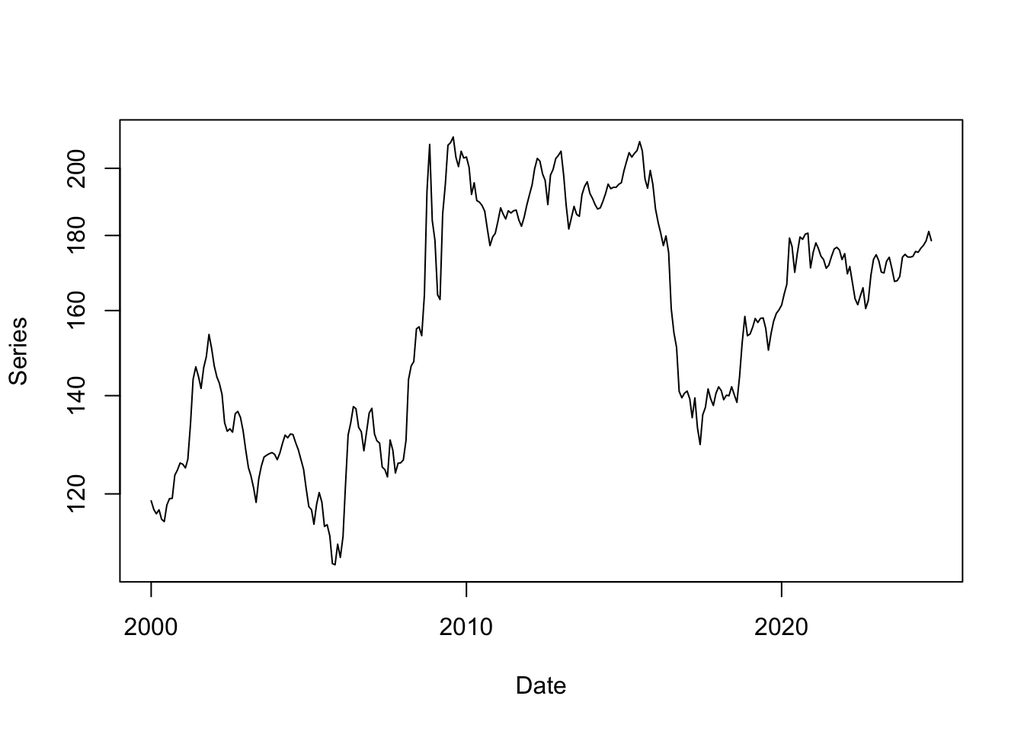

```r
plot(Series ~ Date, FxGBP, log='y', type = "l") #Graf af tímaröðinni
```

## 1. hluti: FX Gengi - ISK/GBP

### a)

**a liður í hluta 1 hefur nú þegar verið svaraður og er hugsaður til að sýna hvernig þið eigið að svara þessu skilaverkefni**

Reiknið mánaðarlega gengisbreytingu og árlega gengisbreytingu. Út frá mánaðarlegri gengisbreytingu, reiknið einnig einfalda ávöxtun raðarinnar.

```r
# Hér er R-kóðablokk.
# Nauðsynlegt er að hafa mismunandi heiti á öllum blokkum í .Rmd skránni
# T.d. heitir þessi blokk 'FxGBP'

#Hér er t.d. svar við lið a)
# Þetta hér er mánaðarleg gengisbreyting ISK/GBP (s.s. mánaðarleg lograávöxtun tímaraðarinnar)
logFxReturn <- diff(log(FxGBP$Series))

#Þetta er einföld ávöxtun raðarinnar fundinn út frá mánaðarlegri ávöxtun raðarinnar
basicFxReturn <- exp(logFxReturn)-1

#Hér er verið að gera árlega gengisbreytingu ISK/GBP (s.s. árleg lograávöxtun tímaraðarinnar)
log_year_FxReturn <- diff(log(FxGBP$Series), lag = 12)


# svar við b) lið gæti t.d. byrjað með skipun
# basicStats(...)
```

**Svar við a) lið:** *Mismunaröð gengisrununnar gefur okkur tímaröð gengisbreytingar. Hægt er að breyta lograávöxtun, í einfalda ávöxtun raðarinnar með að setja log ávöxtun í veldisvísi á e eins og sést í kóða hér að ofan.*

### b)

**Sýnið væntigildi, flökt, skeifni og umframreisni mánaðarlegrar gengisbreytingu (logFxReturn).**

**Lausn**

```r
basic<- basicStats(logFxReturn)
cat("væntigildi:", basic[7,], "\n")
```

```
## væntigildi: 0.001375
```

```r
cat("flökt:", basic[14,]*sqrt(12), "\n")   #ársflökt
```

```
## flökt: 0.1000294
```

```r
cat("skeifni:", basic[15,], "\n")
```

```
## skeifni: 0.826255
```

```r
cat("umframreisni:", basic[16,], "\n")
```

```
## umframreisni: 5.560872
```

### c)

**Hefur mánaðarleg gengisbreyting (e. logFxReturn) marktækt fyrsta, þriðja og fjórða vægi (e. moments)? Þ.e.a.s., er væntigildi, skeifni og umframreisn raðarinnar jákvætt frábrugðið núlli?**

**Lausn**

**Fyrsta vægi**

Notum tilgátupróf:  
$H_0:\mu=0\\ H_1:\mu\neq0$

```r
prof<- t.test(logFxReturn, mu = 0, na.rm = T)
cat(capture.output(prof)[c(5,6)], sep = "\n")
```

```
## t = 0.8204, df = 296, p-value = 0.4126
## alternative hypothesis: true mean is not equal to 0
```

p gildi:0.4126 er stærri en marktektarkrafan $\alpha=0.05$. Höfum ekki nóg gögn til að hafna núlltilgátu. Drögum ályktun að fyrsta vægi sé ekki marktækt og væntigildi er ekki frábrugðið núlli.

**Þriðja vægi**

Notum tilgátupróf:  
$H_0:\hat{S}(r)=0\\ H_1:\hat{S}(r)\neq0$  
Fómula til að reikna prófstikann: $\text{t ratio}=\frac{\hat{S}(r)}{\sqrt{6/T}}$  
Ef $|t|>Z_{\alpha/2}$ þá höfnum núlltilgátu (marktektarkrafan $\alpha=0.05$).

```r
# notum fomula og reiknum t-ratio statistic
t<- basic[15,]/sqrt(6/basic[1,])

# z-gildi
a<- 0.05
z<- qnorm(a/2, lower.tail = F)
cat("|t|=", t,"\n", "z gildi=", z, "\n", ifelse(abs(t)>z, "höfnum núlltillgátu", "höfnum ekki núlltillgátu"), sep = " ")
```

```
## |t|= 5.813219
##  z gildi= 1.959964
##  höfnum núlltillgátu
```

Drögum ályktun að þriðja vægi sé marktækt og skeifni er frábrugðið núlli.

Getum einnig keyrið fall í R:

```r
test.skew(logFxReturn)
```

```
##  Skewness p
##    0.8304 0
```

p gildi:0 er minna en marktektarkrafan $\alpha=0.05$. Höfnum núlltilgátu og drögum sama ályktun og við notum tilgátupróf.

**Fjórða vægi**

Notum tilgátupróf:  
$H_0:\hat{K}(r)-3=0\\ H_1:\hat{K}(r)-3\neq0$

Fómula til að reikna prófstikann: $\text{t ratio}=\frac{\hat{K}(r)-3}{\sqrt{24/T}}$  
Ef $|t|>Z_{\alpha/2}$ þá höfnum núlltilgátu (marktektarkrafan $\alpha=0.05$).

```r
# notum fomula og reiknum t-ratio statistic
t<- basic[16,]/sqrt(24/basic[1,])

# z-gildi
a<- 0.05
z<- qnorm(a/2, lower.tail = F)
cat("|t|=", t,"\n", "z gildi=", z, "\n", ifelse(abs(t)>z, "höfnum núlltillgátu", "höfnum ekki núlltillgátu"), sep = " ")
```

```
## |t|= 19.5621
##  z gildi= 1.959964
##  höfnum núlltillgátu
```

Drögum ályktun að fjórða vægi sé marktækt og umframreisni er frábrugðið núlli.

Getum einnig keyrið fall í R:

```r
test.kurtosis(logFxReturn)
```

```
##  Kurtosis Excess p
##    8.6188 5.6188 0
```

p gildi:0 er minna en marktektarkrafan $\alpha=0.05$. Höfnum núlltilgátu og drögum sama ályktun og við notum tilgátupróf.

### d)

**Fylgir mánaðarleg gengisbreyting normaldreifingu? Gerið formlegt próf til að athuga þessa tilgátu og berið dreifingu saman við normaldreifingu á mynd. Ef hún er frábrugðin normaldreifingu, hvernig?**

**Lausn**

Notum Jarque-Bera próf:
Tilgátur:
$$H_0:JB=0,\ \text{gögnin fylgja normaldreifingu}\\
H_1:JB\neq0,\ \text{gögnin fylgja ekki normaldreifingu}$$

```r
prof<- jarqueberaTest(logFxReturn)
cat(capture.output(prof)[c(3,6:9)], sep = "\n")
```

```
##  Jarque-Bera Normality Test
##   STATISTIC:
##     X-squared: 424.829
##   P VALUE:
##     Asymptotic p Value: < 2.2e-16
```

p gildi< 2.2e-16 er minna en marktektarkrafan $\alpha=0.05$. Höfnum núlltilgátu og drögum ályktun að gögnin séu ekki normaldreifð.

Berum dreifingu saman við normaldreifingu á mynd.

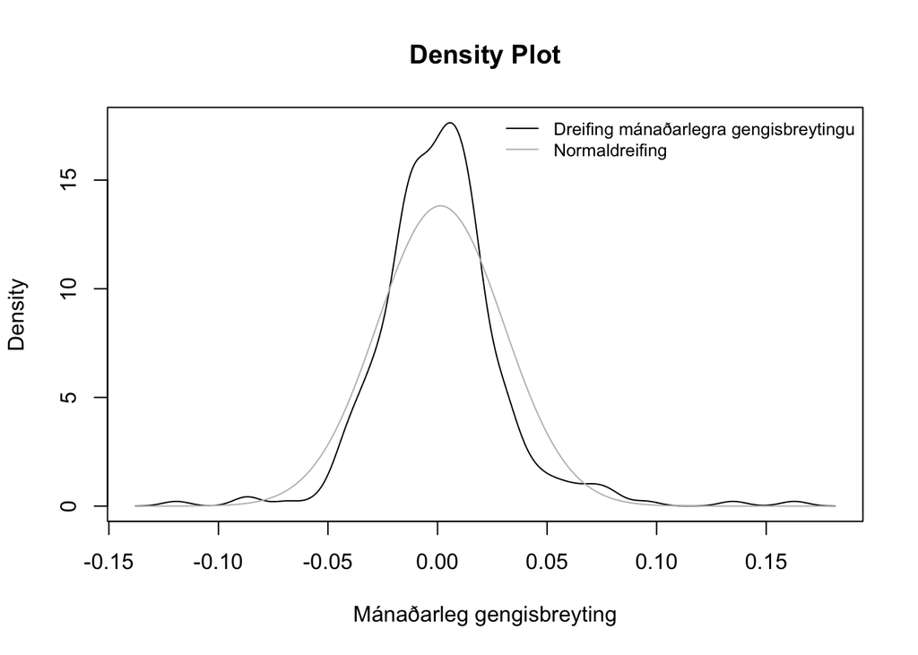

```r
#get empirical density
den <- density(logFxReturn, na.rm = T)

#fit normal density
normx <- seq(min(den$x), max(den$x), 0.001)
normy <- dnorm(normx, mean = basic[7,], sd = basic[14,])

#compare empirical density with normal density
plot(den$x, den$y, type='l', xlab="Mánaðarleg gengisbreyting", ylab="Density", main="Density Plot")

#normal distribution line
lines(normx, normy, col="grey")

legend("topright", c("Dreifing mánaðarlegra gengisbreytingu", "Normaldreifing"), col=c("black", "grey"), lty=c(1,1), bty = "n", cex = 0.8)
```

Dreifing mánaðarlegra gengisbreytingu á nokkrar sveiflur í hölunum. Umframreisni: 5.560872 sýnir líka að halinn mánaðarlegra gengisbreytingu er feitari en normaldreifing og fær meira extreme gildi. Auk þess er bjögun til staðar sem efri halinn teygir sig lengra (er saman við bjögun 0.826255).

## 2. hluti: Sjálffylgni og val á líkani

### a)

**Sýnið sjálffylgnifall mánaðarlegrar gengisbreytingu. Hvernig sýnir sú mynd hvort það sé sjálffylgni í tímaröðinni?**

**Lausn**

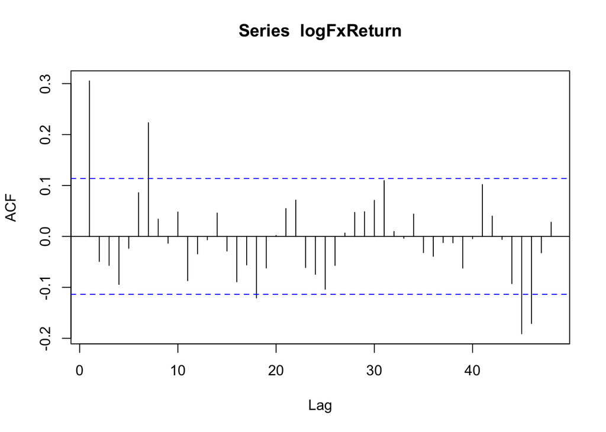

```r
Acf(logFxReturn, lag.max = 48, ci=0.95)
```

```r
g<- Acf(logFxReturn, plot = F, lag.max = 48, ci=0.95)

# reiknum 95% öryggisbili
T<- length(logFxReturn)
nedri<- qnorm(0.025, lower.tail = T)/sqrt(T)
efri<- qnorm(0.025, lower.tail = F)/sqrt(T)

# tekka marktæk lög
s<- g$lag[which(abs(g$acf)>efri)]
```

95% öryggisbil á myndinni (bláu brotalínurnar) er [-0.1137286,0.1137286]. Sjálfsfylgni í lag 1, 7, 18, 45, 46 sem fara yfir bláu dotted línurnar séu marktæk sjálfflygni miðað við marktektarkröfu $\alpha=0.05$. Þetta þýðir að sjálffylgni í lag 1, 7, 18, 45, 46 séu til staðar í tímaröðinni.

### b)

**sýnið með formúlu hvernig fylgni við fyrsta stigs tafða lið er reiknuð. Hvernig segjum við til að slík fylgni sé marktæk eða ekki? Sýnið útreikninga.**

**Lausn**

```r
dreifni<- var(logFxReturn)
samdreifni<- sum((logFxReturn[2:T]-mean(logFxReturn))*(logFxReturn[1:(T-1)]-mean(logFxReturn))/(T-1))
```

Fomula til að reikna $\rho_1$ er:
$$\rho_1=\frac{Cov(r_t,r_{t-1})}{Var(r_t)}=\frac{2.5446026\times
10^{-4}}{8.3384206\times 10^{-4}}=0.305166$$
stemma af við skipun:

```r
v<- Acf(logFxReturn, plot = F)$acf
cat("Sjálffylgni við fyrsta stigs tafða lið er:", v[2], "\n")
```

```
## Sjálffylgni við fyrsta stigs tafða lið er: 0.305166
```

Notum tilgátupróf til að meta hvort $\rho_1$ sé marktækt:  
$H_0:\hat{\rho_1}=0 \\ H_1:\hat{\rho_1}\neq0$

Prófstikinn er: $\text{t ratio}=\frac{\hat{\rho_1}}{\sqrt{1/T}}=\frac{0.305166}{\sqrt{1/297}}=5.2591358$

Veljum marktektarkröfu $\alpha=0.05$.

Hvarfgildi er: $Z_{\alpha/2}=Z_{0.025}=1.959964$

Vegna þess að $|\text{t ratio}|>Z_{\alpha/2},\ (|5.2591358|>1.959964)$ höfnum $H_0$ og ályktum að fyrsta sjálffylgni er marktækt.

Getum einnig notað Ljung-Box prófstikinn $Q(1)$ með sömu tilgátur:  
$H_0:\hat{\rho_1}=0 \\ H_1:\hat{\rho_1}\neq0$

```r
prof<- Box.test(logFxReturn, lag = 1, type = "Ljung-Box")
cat(capture.output(prof)[c(2,5)], sep = "\n")
```

```
##  Box-Ljung test
## X-squared = 27.939, df = 1, p-value = 1.252e-07
```

p-gildið:1.252e-07 er minna en marktektarkrafan $\alpha=0.05$. Höfnum $H_0$ og ályktum að $\hat{\rho_1}\neq0$.

### c)

**Notið fallið ar() til að velja *p* í AR(*p*) líkani fyrir mánaðarlega gengisbreytingu. Er það líkan “rétt skilgreint” og er það gott líkan? Rökstyðjið.**

**Lausn**

Notum ar() til að ákvarða RA-liði

```r
# maximum likelihood estimation
g<- ar.mle(logFxReturn)

# Find the AR order
cat("AR order:", g$order, "\n")
```

```
## AR order: 8
```

Búum til `AR(8)` líkan og tékkum sjálffylgni leifanna líkansins (viljum ekki hafa sjálffylgni í leifaliðum líkansins).

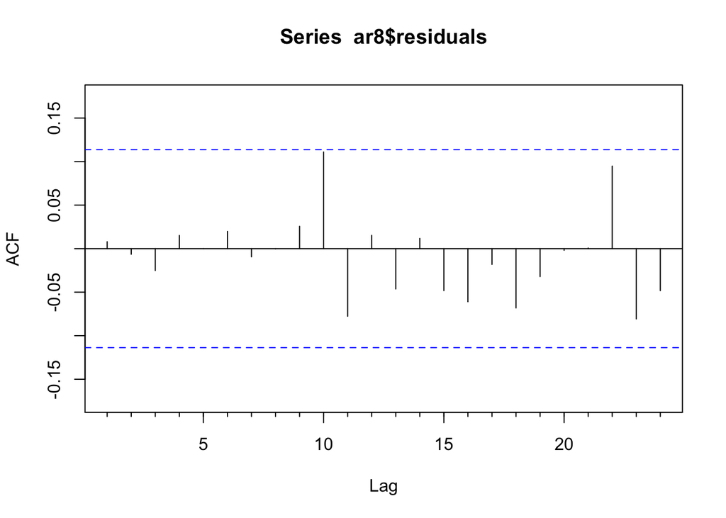

```r
# fit AR(8)
ar8<- arima(logFxReturn,order = c(8,0,0))

# residual standard error
Acf(ar8$residuals, ci=0.95)
```

Nú sé engin sjálffylgni til staðar í leifaliðunum miðað við $\alpha=0.05$ marktektarkröfu.

Prófum Ljung-Box próf fyrir leifaliði `AR(8)` líkansins:

```r
# Ljung-Box test
prof<- Box.test(ar8$residuals, lag = 12, type = "Ljung")
cat(capture.output(prof)[c(2,5)], sep = "\n")
```

```
##  Box-Ljung test
## X-squared = 6.4042, df = 12, p-value = 0.8943
```

Í Ljung-Box prófi fyrir leifaliði `AR(8)` líkansins getum við ekki hafnað núlltilgátunni að engin sjálffylgni sé til staðar í leifaliðunum miðað við $\alpha=0.05$ marktektarkröfu. Þannig að `AR(8)` líkan sé nógt að útskýra breytileika (e. variability) í mánaðarlegri gengisbreytingu.

Skoðum samantekt `AR(8)`:

```r
prof<- summary(ar8)
cat(capture.output(prof)[c(3:13)], sep = "\n")
```

```
## arima(x = logFxReturn, order = c(8, 0, 0))
##
## Coefficients:
##          ar1      ar2     ar3      ar4     ar5      ar6     ar7      ar8
##       0.3628  -0.1704  0.0687  -0.1144  0.0478  -0.0136  0.2241  -0.1075
## s.e.  0.0576   0.0599  0.0606   0.0607  0.0605   0.0604  0.0595   0.0571
##       intercept
##          0.0014
## s.e.     0.0022
##
## sigma^2 estimated as 0.0006885:  log likelihood = 659.53,  aic = -1301.06
```

```r
# extract se from model
se<- sqrt(diag(vcov(ar8)))

# z gildi
a<- 0.05
z<- qnorm(a/2, lower.tail = F)

# tékkum marktækni stuðlanna
cat("Marktækir stuðlar:", "\n")
```

```
## Marktækir stuðlar:
```

```r
which(abs(coef(ar8))-se*z>0)
```

```
## ar1 ar2 ar7
##   1   2   7
```

Þetta líkan er rétt skilgreint en ekki gott. Skv. gildi staðalfrávika eru stuðlar í tafða líð 1, 2, 7 marktækt frábrugðnir núlli. Þannig að það væri hægt að henda öðrum ómarktækum stuðlum út úr líkaninu til að einfalda líkan. Getum einnig prófað `AR(7)` líkan vegna þess að stuðull $\phi_8$ er ekki fráburðið núlli í `AR(8)` líkani.

### d)

**Skoðið PACF, EACF og skipunina auto.arima() fyrir mánaðarlega gengisbreytingu.**

**i. Útskýrið hvað PACF sýnir**

**Lausn**

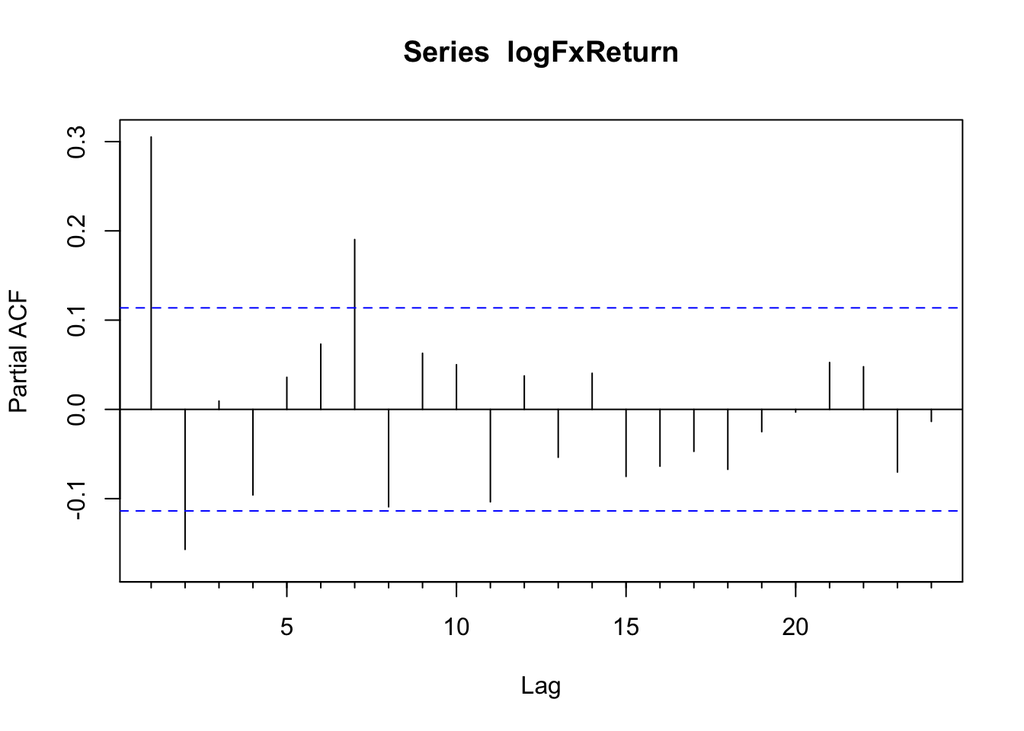

```r
Pacf(logFxReturn, ci=0.95)
```

```r
g<- Pacf(logFxReturn, plot = F, ci=0.95)
```

PACF sýnir að sjálffylgni í lag 1, 2, 7 séu til staðar miðað við $\alpha=0.05$ marktektarkröfu. Eftir lag 7 verður marktækt sjálffylgni ekki til. PACF sýnir okkur hvaða fjöldi $p$ getum við valið fyrir AR($p$) líkan. T.d. í þessari mynd gætum valið $p=7$ fyrir AR líkan.

**ii. Útskýrið hvað EACF sýnir**

**Lausn**

```r
eacf(logFxReturn)
```

```
## AR/MA
##   0 1 2 3 4 5 6 7 8 9 10 11 12 13
## 0 x o o o o o x o o o o  o  o  o
## 1 x x o o o o x o o o o  o  o  o
## 2 o x o o o o x o o o x  o  o  o
## 3 o x x o o o x o o o o  o  o  o
## 4 x x x o o o x o o x x  o  o  o
## 5 x o x x o o x o o o x  o  o  o
## 6 x o x x x x x o o o x  o  o  o
## 7 x o x o x x o o o o o  o  o  o
```

**iii. Útskýrið líkanið sem skipunin auto.arima() mælir með. Hvernig velja slíkar skipanir stig í ARIMA líkani?**

**Lausn**

```r
auto.arima(logFxReturn, trace = T, seasonal = T, ic = "aic")
```

```
##
##  Fitting models using approximations to speed things up...
##
##  ARIMA(2,0,2) with non-zero mean : Inf
##  ARIMA(0,0,0) with non-zero mean : -1259.724
##  ARIMA(1,0,0) with non-zero mean : -1286.089
##  ARIMA(0,0,1) with non-zero mean : -1294.332
##  ARIMA(0,0,0) with zero mean     : -1261.049
##  ARIMA(1,0,1) with non-zero mean : -1292.315
##  ARIMA(0,0,2) with non-zero mean : -1293.193
##  ARIMA(1,0,2) with non-zero mean : -1290.655
##  ARIMA(0,0,1) with zero mean     : -1295.958
##  ARIMA(1,0,1) with zero mean     : -1293.886
##  ARIMA(0,0,2) with zero mean     : -1294.767
##  ARIMA(1,0,0) with zero mean     : -1287.705
##  ARIMA(1,0,2) with zero mean     : -1292.121
##
##  Now re-fitting the best model(s) without approximations...
##
##  ARIMA(0,0,1) with zero mean     : -1295.823
##
##  Best model: ARIMA(0,0,1) with zero mean
```

```
## Series: logFxReturn
## ARIMA(0,0,1) with zero mean
##
## Coefficients:
##          ma1
##       0.3810
## s.e.  0.0575
##
## sigma^2 = 0.000738:  log likelihood = 649.91
## AIC=-1295.82   AICc=-1295.78   BIC=-1288.44
```

auto.arima() mælir með `MA(1)` líkan með jöfnu:
$$r_t=a_t+0.3810a_{t-1},\ \ \hat{\sigma_a}=0.02716616$$
`MA(1)` líkan er valið vegna þess að `MA(1)` fær læsta AIC gildi. Líkanið sýnir að gildi tímaraðarinnar $r$ á tíma $t$ er hermt sem vegið meðaltal af leifaliðum fyrri tímabila $a_{t-1}$. AR(0) þýðir að $r_t$ er óháð fyrri gildum $r_{t-i},\ \ \text{þar sem}\ i\in Z^+$. I(0) þýðir að gögnin þurfa ekki mismun.

Tékkum þá leifar líkansins:

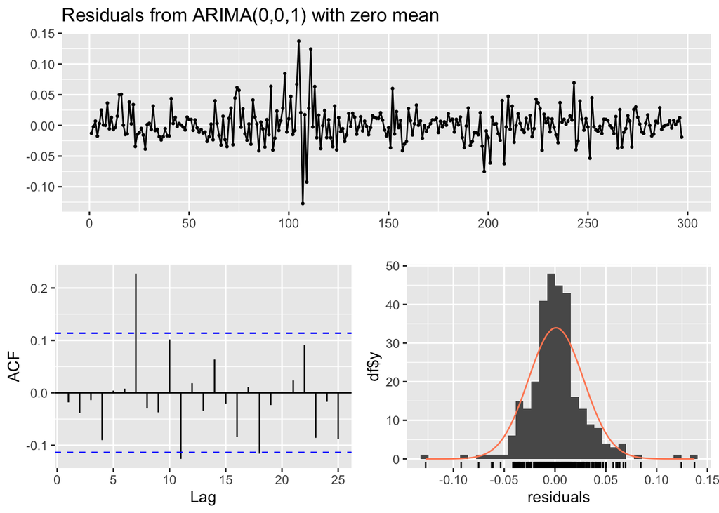

```r
# búum til MA(1)
ma1<- arima(logFxReturn, order = c(0,0,1), include.mean = F)

# tékkum leifar
checkresiduals(ma1, test = F)
```

```r
prof<- Box.test(ma1$residuals, type = "Ljung", lag = 12)
cat(capture.output(prof)[c(2,5,6)], sep = "\n")
```

```
##  Box-Ljung test
## X-squared = 27.859, df = 12, p-value = 0.005802
```

```r
prof<- adfTest(ma1$residuals, lag = 12, type = "nc")
cat(capture.output(prof)[c(3,6:11)], sep = "\n")
```

```
##  Augmented Dickey-Fuller Test
##   PARAMETER:
##     Lag Order: 12
##   STATISTIC:
##     Dickey-Fuller: -4.3879
##   P VALUE:
##     0.01
```

```r
prof<- jarqueberaTest(ma1$residuals)
cat(capture.output(prof)[c(3,6:9)], sep = "\n")
```

```
##  Jarque-Bera Normality Test
##   STATISTIC:
##     X-squared: 311.7377
##   P VALUE:
##     Asymptotic p Value: < 2.2e-16
```

Mynd fyrir ofan sýnir að þyrping flöktsins er til staðar í leifunum.

Miðað við Ljung-Box próf fyrir leifaliði `MA(1)` líkansins getum við hafnað núlltilgátunni miðað við $\alpha=0.05$ marktektarkröfu. Það þýðir að nokkur sjálffylgni sé til staðar í leifaliðunum. ACF mynd sýnir okkur líka að sjálffylgni í lög 7,11 séu marktæk.

Dickey-Fuller próf sýnir að leifar líkansins eru sístæð.

Jarque-Bera próf sýnir að leifar fylgja ekki normaldreifingu. Density mynd til hægri sýnir hvernig leifar er dreift.

Valið líkan úr auto.arima() sé ekki nógt að útskýra breytileika gagnanna skv. greiningum á leifar líkansins.

## 3. hluti: Árstíðarsveifla og spágerð

### a)

**Athugið fyrir árstíðasveiflu í mánaðarlegri lograávöxtun. Notist við SARIMA(2,0,0)x(4,0,0) en þið þurfið sjálf að finna árstíðasveifluna. Hvernig er hún valin?**

**Lausn**

Skóðum fyrst tímaröðin og ACF/PACF myndir:

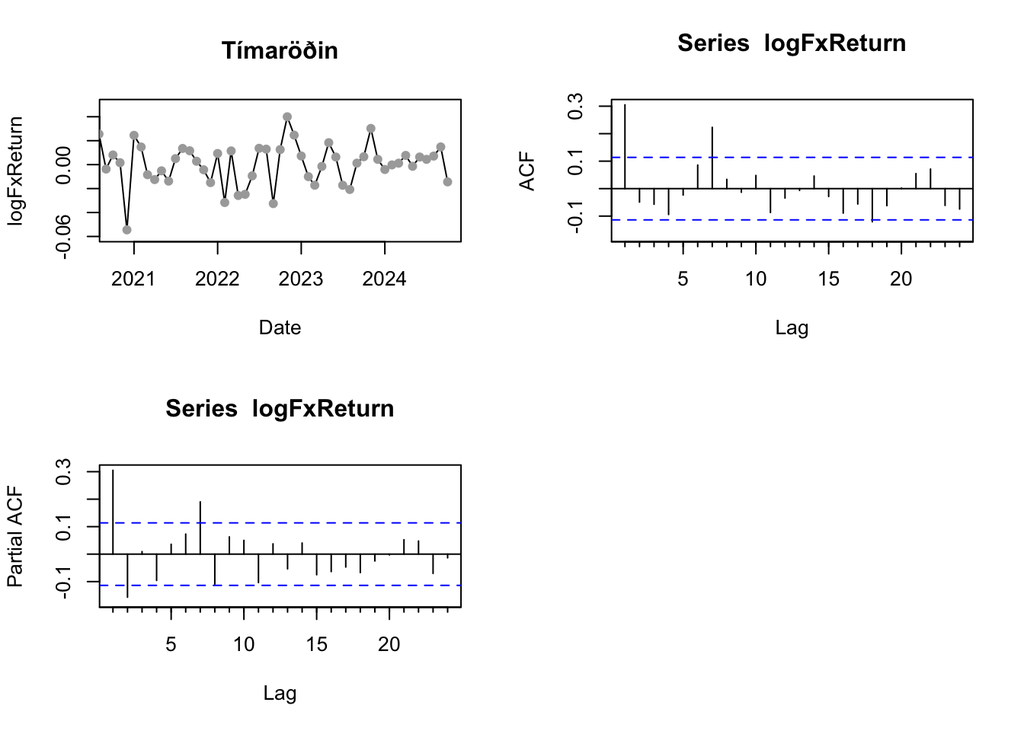

```r
# m_seasonal <- arima(logFxReturn, order = c(2,0,0), seasonal =list(order=c(4,0,0), period=...))
# hér þurfið þið að velja árstíðasveiflu
# Styðjist við útskýringar á árstíðabundnum líkönum á bls. 83 í kennslubók

# tímaröðin
FxGBP$logFxReturn<- c(NA,logFxReturn)
par(mfrow = c(2, 2))
plot(logFxReturn~Date, FxGBP, type = "l", main = "Tímaröðin", ylim = c(-0.06,0.05), xlim = c(18536,19997))
points(FxGBP$Date, FxGBP$logFxReturn, pch=16, col="darkgrey")

Acf(logFxReturn)
Pacf(logFxReturn)
```

Búum til `SARIMA(2,0,0)x(4,0,0)[7]` líkan:

```r
m_seasonal<- arima(logFxReturn, order = c(2,0,0), seasonal = list(order=c(4,0,0), period=7))
m_seasonal
```

```
##
## Call:
## arima(x = logFxReturn, order = c(2, 0, 0), seasonal = list(order = c(4, 0, 0),
##     period = 7))
##
## Coefficients:
##          ar1      ar2    sar1    sar2    sar3    sar4  intercept
##       0.3572  -0.1581  0.2242  0.0003  -0.005  0.0350     0.0014
## s.e.  0.0577   0.0581  0.0576  0.0590   0.060  0.0582     0.0025
##
## sigma^2 estimated as 0.0006953:  log likelihood = 658.06,  aic = -1302.12
```

Tékkum leifar líkansins:

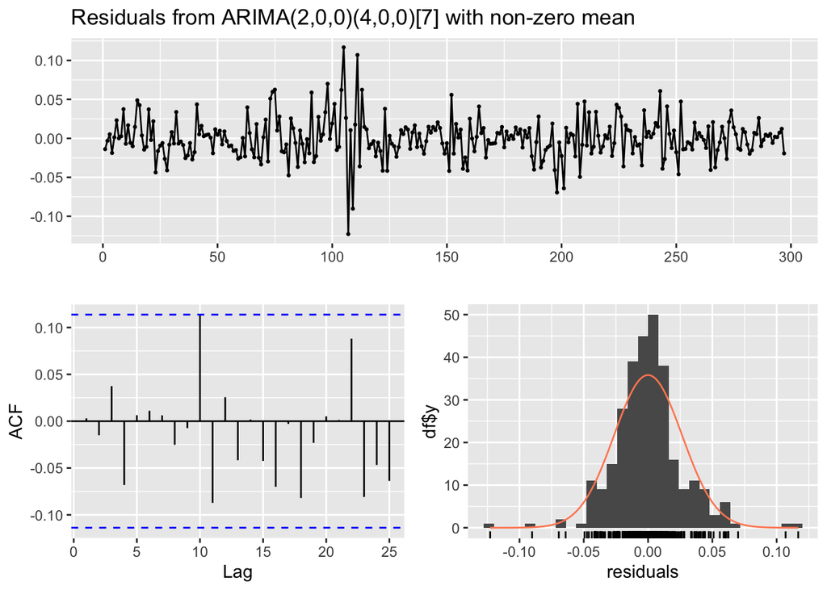

```
##
##  Ljung-Box test
##
## data:  Residuals from ARIMA(2,0,0)(4,0,0)[7] with non-zero mean
## Q* = 6.1375, df = 4, p-value = 0.1891
##
## Model df: 6.   Total lags used: 10
```

```r
checkresiduals(m_seasonal)
```

Skv. leifarathugun er `SARIMA(2,0,0)x(4,0,0)[7]` nógt til að útskýra gögnin okkar. En nokkrir stuðlar séu ekki marktækir. Tékkum marktækni stuðlanna í líkani með marktektarkrafan $\alpha=0.05$:

```r
# extract se from model
se<- sqrt(diag(vcov(m_seasonal)))

# z gildi
a<- 0.05
z<- qnorm(a/2, lower.tail = F)

# tékkum marktækni stuðlanna
cat("Marktækir stuðlar:", "\n")
```

```
## Marktækir stuðlar:
```

```r
which(abs(coef(m_seasonal))-se*z>0)
```

```
##  ar1  ar2 sar1
##    1    2    3
```

Getum enfaldað `SARIMA(2,0,0)x(4,0,0)[7]`, henda ómarktæka stuðla út úr líkani og berum likön saman miðað við AIC gildi:

```r
m_seasonal1<- arima(logFxReturn, order = c(2,0,0), seasonal = list(order=c(1,0,0), period=7), include.mean = F)

# AIC
cat("AIC SARIMA(2,0,0)x(4,0,0)[7]:", m_seasonal$aic, "AIC SARIMA(2,0,0)x(1,0,0)[7]:", m_seasonal1$aic, sep = "\n")
```

```
## AIC SARIMA(2,0,0)x(4,0,0)[7]:
## -1302.122
## AIC SARIMA(2,0,0)x(1,0,0)[7]:
## -1309.453
```

`SARIMA(2,0,0)x(1,0,0)[7]` sé betra en `SARIMA(2,0,0)x(4,0,0)[7]`.

### b)

**Veljið ykkur líkan út frá röksemdarfærslum ykkar í liðum hér að ofan. Setjið fram formlegt próf til að athuga hvort líkanið sem þið veljið hafi sjálffylgni í leifaliðum. Útskýrið hvernig slík próf eru framkvæmd og sýnið.**

**Lausn**

Veljum `SARIMA(2,0,1)(1,0,0)[7]` líkan út frá færslum í liðum að ofan(MA líkan úr auto.arima() bætir við SARIMA líkan sem við finnum áður):

```r
ar2ma1<- arima(logFxReturn, order = c(2,0,1), seasonal = list(order=c(1,0,0), period=7))
ar2ma1
```

```
##
## Call:
## arima(x = logFxReturn, order = c(2, 0, 1), seasonal = list(order = c(1, 0, 0),
##     period = 7))
##
## Coefficients:
##           ar1      ar2     ma1    sar1  intercept
##       -0.0707  -0.0143  0.4356  0.2224     0.0014
## s.e.   0.3957   0.1582  0.3924  0.0566     0.0026
##
## sigma^2 estimated as 0.0006952:  log likelihood = 658.1,  aic = -1306.2
```

Tékkum marktækni stuðlanna í líkani með marktektarkrafan $\alpha=0.05$:

```r
# extract se from model
se<- sqrt(diag(vcov(ar2ma1)))

# z gildi
a<- 0.05
z<- qnorm(a/2, lower.tail = F)

# tékkum marktækni stuðlanna
cat("Marktækir stuðlar:", "\n")
```

```
## Marktækir stuðlar:
```

```r
which(abs(coef(ar2ma1))-se*z>0)
```

```
## sar1
##    4
```

Meðaltalið, ar1, ar2, ma1 eru ekki marktæk í líkani.

Enföldum líkan til `SARIMA(1,0,1)(1,0,0)[7]` (sleppum fyrst hægra tafða lið og meðatali):

```r
ar1ma1<- arima(logFxReturn, order = c(1,0,1), seasonal = list(order=c(1,0,0), period=7), include.mean = F)
ar1ma1
```

```
##
## Call:
## arima(x = logFxReturn, order = c(1, 0, 1), seasonal = list(order = c(1, 0, 0),
##     period = 7), include.mean = F)
##
## Coefficients:
##           ar1     ma1    sar1
##       -0.1001  0.4662  0.2228
## s.e.   0.1540  0.1376  0.0562
##
## sigma^2 estimated as 0.0006959:  log likelihood = 657.96,  aic = -1309.92
```

Tékkum marktækni stuðlanna í líkani með marktektarkrafan $\alpha=0.05$:

```r
# extract se from model
se<- sqrt(diag(vcov(ar1ma1)))

# z gildi
a<- 0.05
z<- qnorm(a/2, lower.tail = F)

# tékkum marktækni stuðlanna
cat("Marktækir stuðlar:", "\n")
```

```
## Marktækir stuðlar:
```

```r
which(abs(coef(ar1ma1))-se*z>0)
```

```
##  ma1 sar1
##    2    3
```

ar1 er ekki marktæk í líkani.  
Enföldum líkan til `SARIMA(0,0,1)(1,0,0)[7]`:

```r
ma1sar1<- arima(logFxReturn, order = c(0,0,1), seasonal = list(order=c(1,0,0), period=7), include.mean = F)
ma1sar1
```

```
##
## Call:
## arima(x = logFxReturn, order = c(0, 0, 1), seasonal = list(order = c(1, 0, 0),
##     period = 7), include.mean = F)
##
## Coefficients:
##          ma1    sar1
##       0.3797  0.2251
## s.e.  0.0560  0.0560
##
## sigma^2 estimated as 0.0006968:  log likelihood = 657.76,  aic = -1311.51
```

Þetta líkan er sama og `ARMA(7,1)` líkan án árstíðasveiflu:

```r
ar7ma1<- arima(logFxReturn, order = c(7,0,1), include.mean = F, fixed = c(0,0,0,0,0,0,NA,NA))
ar7ma1
```

```
##
## Call:
## arima(x = logFxReturn, order = c(7, 0, 1), include.mean = F, fixed = c(0, 0,
##     0, 0, 0, 0, NA, NA))
##
## Coefficients:
##       ar1  ar2  ar3  ar4  ar5  ar6     ar7     ma1
##         0    0    0    0    0    0  0.2251  0.3797
## s.e.    0    0    0    0    0    0  0.0560  0.0560
##
## sigma^2 estimated as 0.0006968:  log likelihood = 657.76,  aic = -1311.51
```

Jafna `ARMA(7,1)` er:
$$r_t=0.2251r_{t-7}+a_t+0.3797a_{t-1},\ \ \ \hat{\sigma_a}=0.02639697$$
Kennijafna líkansins er:
$$(1-0.2251B^7)r_t=(1+0.3797B)a_t$$
Tékkum leifar líkansins:

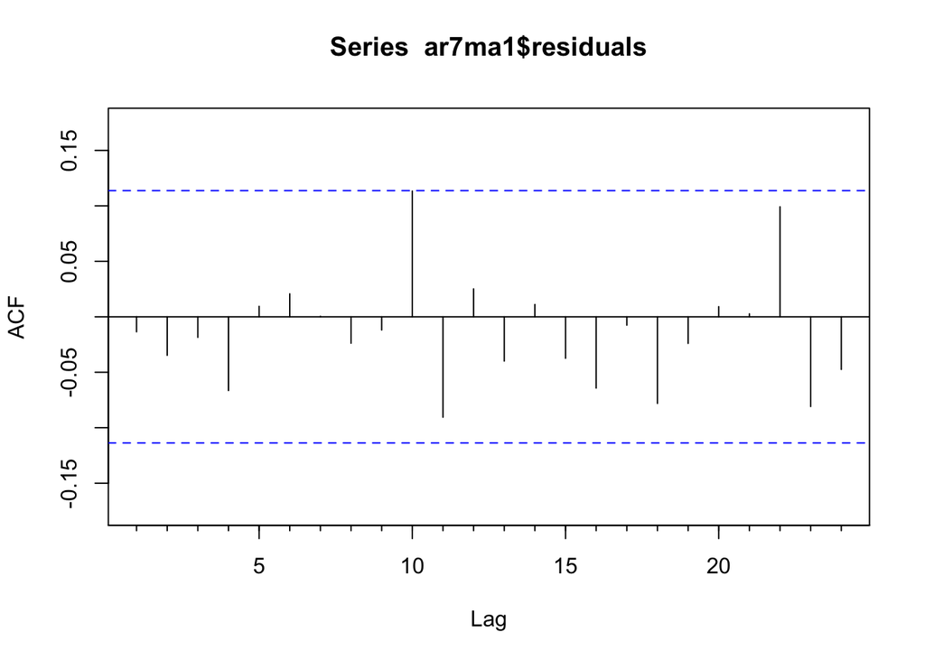

```r
Acf(ar7ma1$residuals)
```

```r
prof<- Box.test(ar7ma1$residuals, type = "Ljung", lag = 24)
cat(capture.output(print(prof))[c(2,5:6)], sep = "\n")
```

```
##  Box-Ljung test
## X-squared = 19.431, df = 24, p-value = 0.7286
```

```r
prof<- adfTest(ar7ma1$residuals, lag = 24)
cat(capture.output(print(prof))[c(3,8:11)], sep = "\n")
```

```
##  Augmented Dickey-Fuller Test
##   STATISTIC:
##     Dickey-Fuller: -4.2068
##   P VALUE:
##     0.01
```

```r
prof<- jarqueberaTest(ar7ma1$residuals)
cat(capture.output(print(prof))[c(3,6:10)], sep = "\n")
```

```
##  Jarque-Bera Normality Test
##   STATISTIC:
##     X-squared: 177.4175
##   P VALUE:
##     Asymptotic p Value: < 2.2e-16
```

ACF og Ljung-Box próf sýna að sjálffylgni leifanna líkansins eru ekki til staðar. Dickey-Fuller próf synir að leifar eru sístæð. Jarque-Bera próf sýnir að leifar líkansins séu ekki normaldreifar.

`ARMA(7,1)` líkan sem við veljum þýðir að spágerð myndi fara eftir því suð í fyrra tíma $a_{t-1}$ og sögulegt gildi í fyrra tíma $t_{7}$. $\phi_0$ í þessu líkan er núll vegna þess að meðaltal er ekki frábrugðið núlli.

**ARCH líkan fyrir flökt**

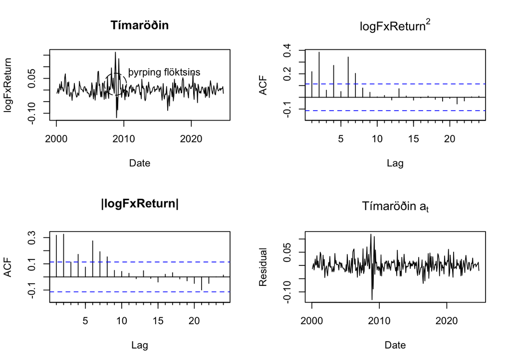

```r
par(mfrow = c(2, 2))
plot(logFxReturn~Date, FxGBP, type = "l", main = "Tímaröðin")
symbols(14153, 0.025, circles = 600, inches = FALSE, add = TRUE, lty=5)
text(16805,0.075,"þyrping flöktsins")

Acf(logFxReturn^2, lag.max = 24, main = expression("logFxReturn"^2))
Acf(abs(logFxReturn), lag.max = 24, main = "|logFxReturn|")

at<- residuals(ar7ma1)
FxGBP$Residual<- c(NA, at)

# residuals timarodin
plot(Residual~Date, FxGBP, type = "l", main = expression("Tímaröðin"~a[t]))
```

Vegna forvitnis og vegna þess að við finnum þyrping flöktsins í tímaröðinni og háð samband á ACF myndunum fyrir ofan. Flökt virðist ekki stöðugt. Notum leifar líkansins sem gögnin til að tékka ARCH áhrif.

Tékkum ARCH áhrif (Box-Ljung próf):
$$H_0: \alpha^2_1=...=\alpha^2_i=0\\
H_1: \alpha^2_i\neq0, \ \ \text{for some }i\in\{1,...,24\}$$

```r
prof<- Box.test(at^2, lag=24, type = "Ljung")
cat(capture.output(prof)[c(2,5)], sep = "\n")
```

```
##  Box-Ljung test
## X-squared = 156.12, df = 24, p-value < 2.2e-16
```

p-gildið < 2.2e-16 er minna en marktektarkrafan $\alpha=0.05$. Höfnum $H_0$ og ályktum að $\alpha^2_i\neq0, \ \text{for some}\ i\in\{1,...,24\}$. ARCH effect er til staðar.

Tímaröðin leifanna $a_t$ lítur svipað út og tímaröðin gagnanna (logFxReturn). Þannig að við notum logFxReturn til að búa til ARCH líkan.

Prófum `ARMA(7,1)+ARCH(1)` með skewed Student-t dreifingu (sstd). *Sleppum fastanum Omega í ARCH(1) vegna þess að hann er ekki marktækur.*:

```r
# búum til GARCH(1,0) model
spec <- ugarchspec(
  mean.model = list(armaOrder = c(7,1), include.mean = F, archm = F),
  variance.model = list(model = "sGARCH", garchOrder = c(1,0)),
  distribution.model = "sstd",
  fixed.pars=list(omega=0, ar1=0, ar2=0,ar3=0,ar4=0,ar5=0,ar6=0, ar7=0.2251, ma1=0.3797)
  )

arch1 <- ugarchfit(spec,logFxReturn)
cat(capture.output(arch1)[c(8:10,13:27,45:75)], sep = "\n")
```

```
## GARCH Model  : sGARCH(1,0)
## Mean Model   : ARFIMA(7,0,1)
## Distribution : sstd
## ------------------------------------
##         Estimate  Std. Error  t value Pr(>|t|)
## ar1       0.0000          NA       NA       NA
## ar2       0.0000          NA       NA       NA
## ar3       0.0000          NA       NA       NA
## ar4       0.0000          NA       NA       NA
## ar5       0.0000          NA       NA       NA
## ar6       0.0000          NA       NA       NA
## ar7       0.2251          NA       NA       NA
## ma1       0.3797          NA       NA       NA
## omega     0.0000          NA       NA       NA
## alpha1    0.9990    0.066766   14.963        0
## skew      1.0570    0.036941   28.614        0
## shape     3.0523    0.109542   27.865        0
##
## Information Criteria
## ------------------------------------
##
## Akaike       -2.4967
## Bayes        -2.4594
## Shibata      -2.4969
## Hannan-Quinn -2.4818
##
## Weighted Ljung-Box Test on Standardized Residuals
## ------------------------------------
##                          statistic p-value
## Lag[1]                     0.01047  0.9185
## Lag[2*(p+q)+(p+q)-1][23]   0.36963  1.0000
## Lag[4*(p+q)+(p+q)-1][39]   0.45583  1.0000
## d.o.f=8
## H0 : No serial correlation
##
## Weighted Ljung-Box Test on Standardized Squared Residuals
## ------------------------------------
##                         statistic p-value
## Lag[1]                   0.003853  0.9505
## Lag[2*(p+q)+(p+q)-1][2]  0.005779  0.9937
## Lag[4*(p+q)+(p+q)-1][5]  0.011655  1.0000
## d.o.f=1
##
## Weighted ARCH LM Tests
## ------------------------------------
##             Statistic Shape Scale P-Value
## ARCH Lag[2]  0.003801 0.500 2.000  0.9508
## ARCH Lag[4]  0.008705 1.397 1.611  0.9995
## ARCH Lag[6]  0.012142 2.222 1.500  1.0000
```

Jafna líkansins `ARMA(7,1)+ARCH(1)` er:
$$r_t=0.2251r_{t-7}+a_t+0.3797a_{t-1},\ \ a_t=\sigma_t\epsilon_t\\
\sigma^2_t=0.9990a^2_{t-1}\\
\xi=1.0570\\
\nu=3.0523$$
Ljung-Box próf fyrir leifar sýnir að líkanið er nógt að útskýra breytingu í gögnunum. Ljung-Box próf fyrir $\text{leifar}^2$ (Standardized Squared Residuals) sýnir að líkanið er nógt að útskýra breytingu flöktsins. Lagrange Multiplier próf sýnir að líkanið er nógt að útskýra ARCH áhrif í gögnunum.

Skóðum konditional flökt á mynd:

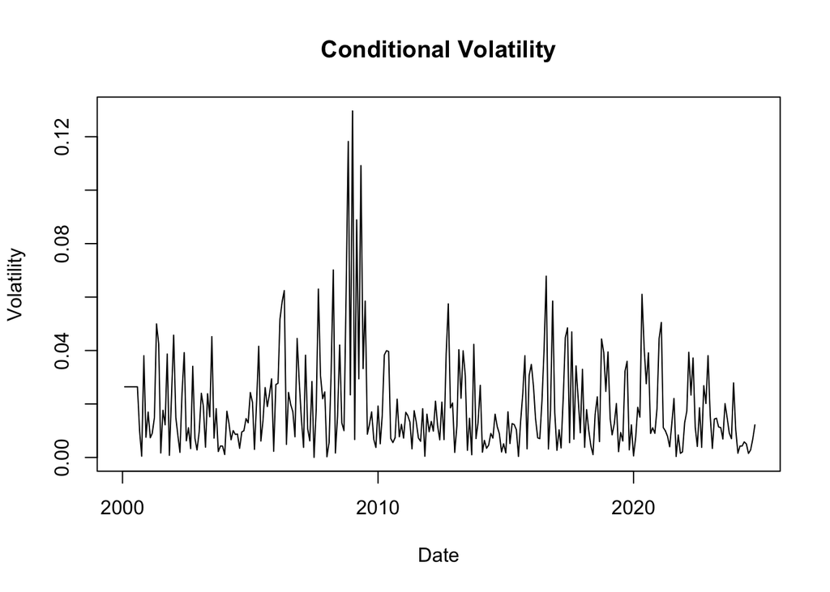

```r
# Extract the conditional volatility
sig <- sigma(arch1)
FxGBP$Volatility<- c(NA, sig)

# Plot the conditional volatility
plot(Volatility~Date, FxGBP, type="l", main = "Conditional Volatility")
```

*Getum notað þetta ARCH(1) til að gera flöktspá.*

### c)

**Gerið spá með AR(2) líkani fyrir mánaðarlega gengisbreytingu (logFxReturn) Reiknið fyrstu tvö spágildi fram í tíma handvirkt og stemmið af með fallinu predict.**

**Lausn**

```r
ar2<- arima(logFxReturn, order = c(2,0,0))
ar2
```

```
##
## Call:
## arima(x = logFxReturn, order = c(2, 0, 0))
##
## Coefficients:
##          ar1      ar2  intercept
##       0.3529  -0.1567     0.0013
## s.e.  0.0573   0.0572     0.0020
##
## sigma^2 estimated as 0.0007348:  log likelihood = 650.07,  aic = -1294.13
```

```r
# reiknum phi0
phi1<- coef(ar2)[1]
phi2<- coef(ar2)[2]
mu<- coef(ar2)[3]
phi0<- mu*(1-phi1-phi2)

# past log return
r1<- logFxReturn[length(logFxReturn)]
r2<- logFxReturn[length(logFxReturn)-1]

# spágildi
spa1<- phi0+phi1*r1+phi2*r2
spa2<- phi0+phi1*spa1+phi2*r1
```

Notum fomula: $\mu=\frac{\phi_0}{1-\phi_1-\phi_2}$ til að finna $\phi_0$:
$$\phi_0=\mu*(1-\phi_1-\phi_2)=0.0013452*(1-0.3528881-(-0.1567385))=0.0010813$$
Líkanið AR(2) er:
$$r_t=0.0010813+(0.3528881)r_{t-1}+(-0.1567385)r_{t-2}+a_t,\
\hat{\sigma_a}=0.02710719$$
Notum líkanið og metum punktspána 2 tímabil fram í tíma:
Fyrsta spágildi: $\hat{r_h}(1)=0.0010813+0.3528881*(-0.0144015)+(-0.1567385)*0.0147937=-0.0063196$
Annað spágildi: $\hat{r_h}(2)=0.0010813+0.3528881*(-0.0063196)+(-0.1567385)*(-0.0144015)=0.0011085$

**Stemmum af með fallinu predict()**

```r
spa<- predict(ar2, n.ahead = 2)
cat("Spágildi 2 tímabil fram í tíma:", capture.output(print(spa$pred))[5], sep = "\n")
```

```
## Spágildi 2 tímabil fram í tíma:
## [1] -0.006319568  0.001108475
```

Fyrsta 2 spágildi i predict() eru sömu og sem við reiknum handvirkt.

### d)

**Gerið spá með líkaninu sem þið völduð ykkur. Spáið 24 mánuði fram í tíman. Útskýrið hvort þið teljið þetta vera góða spá. Skrifið svar ykkar út frá tímabilinu sem horft er á. Svörin eiga að vera skrifuð eins og það er verið að útskýra gengisspá fyrir fjölmiðlum (hugsið um þjóðhagsspá bankanna).**

**Lausn**

```r
#Skoðið tímabilið sem er verið að spá frá
tail(FxGBP$Date)
```

[output not shown]

```r
#Drög að spá
logFxReturn_pred<- predict(ar7ma1,24)$pred
logFxReturn_p_sd<- predict(ar7ma1,24)$se

x<- FxGBP$Date
y<- FxGBP$logFxReturn

# z gildi
a<- 0.2
z<- qnorm(a/2, lower.tail = F)

plot(x, y, type = "l", ylim = c(-0.055,0.055), xlim = c(18536, 20727), xlab = "Date", ylab = "Lograávöxtun breyting", main = "Gengibreytingarþróun")
legend("topleft", c("Söguleg gögn", "Spágildi", "80% öryggisbil"), col=c("black", "darkgray", "grey"), lty=c(1,1,2), pch = c(NA,16,NA), bty = "n")

# spálínur och punktar
lines(c(seq(as.Date("2024-10-01"), as.Date("2026-10-01"), by = "month")),c(y[nrow(FxGBP)],logFxReturn_pred), col = "darkgrey")
points(c(seq(as.Date("2024-11-01"), as.Date("2026-10-01"), by = "month")),logFxReturn_pred, pch=16, col="darkgrey")

# 80% öryggisbil
lines(c(seq(as.Date("2024-10-01"), as.Date("2026-10-01"), by = "month")),c(y[nrow(FxGBP)],logFxReturn_pred-logFxReturn_p_sd*z), col = "grey", lty=2)
lines(c(seq(as.Date("2024-10-01"), as.Date("2026-10-01"), by = "month")),c(y[nrow(FxGBP)],logFxReturn_pred+logFxReturn_p_sd*z), col = "grey", lty=2)
```

[output not shown]

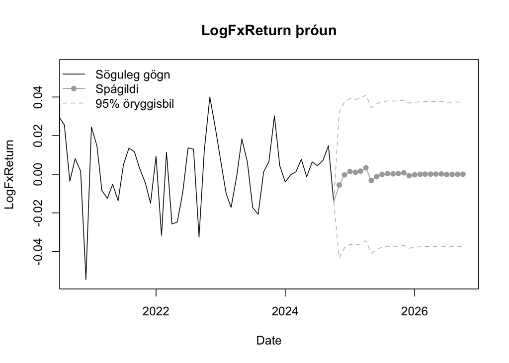

```r
# ARMA(7,1)+ARCH(1) spá
#Drög að spá
gar_pred<- ugarchforecast(arch1, n.ahead = 24)
gar_p_sd<- gar_pred@forecast$sigmaFor
gar_p_m<- gar_pred@forecast$seriesFor

x<- FxGBP$Date
y<- FxGBP$logFxReturn

plot(x, y, type = "l", ylim = c(-0.055,0.055), xlim = c(18536, 20727), xlab = "Date", ylab = "LogFxReturn", main = "LogFxReturn þróun")
legend("topleft", c("Söguleg gögn ", "Spágildi", "95% öryggisbil"), col=c("black", "darkgray", "grey"), lty=c(1,1,2), pch = c(NA,16,NA), bty = "n")

# spálínur och punktar
lines(c(seq(as.Date("2024-10-01"), as.Date("2026-10-01"), by = "month")),c(y[nrow(FxGBP)],gar_p_m), col = "darkgrey")
points(c(seq(as.Date("2024-11-01"), as.Date("2026-10-01"), by = "month")),gar_p_m, pch=16, col="darkgrey")

# z gildi
a<- 0.05
z<- qnorm(a/2, lower.tail = F)

# 95% öryggisbil
lines(c(seq(as.Date("2024-10-01"), as.Date("2026-10-01"), by = "month")),c(y[nrow(FxGBP)],gar_p_m-gar_p_sd*z), col = "grey", lty=2)
lines(c(seq(as.Date("2024-10-01"), as.Date("2026-10-01"), by = "month")),c(y[nrow(FxGBP)],gar_p_m+gar_p_sd*z), col = "grey", lty=2)
```

```r
# percentage change spá
percent<- (exp(gar_p_m)-1)*100

# gengispá
gengi<- FxGBP$Series[length(FxGBP$Date)]

for (i in percent) {
  new_rate<- gengi[length(gengi)]*(1-i)
  gengi <- c(gengi, new_rate)
}

y2<- (gengi[25]-gengi[1])/gengi[1]*100
```

```r
# multiple R squared
rss <- sum(residuals(arch1)^2)
tss <- sum((logFxReturn-mean(logFxReturn))^2)
R2 <- 1-(rss/tss)

# result
cat("Multiple R squared:", R2, "\n")
```

```
## Multiple R squared: 0.1603175
```

Líkanið útskýrir aðeins 16.03% breytingar í mánuðalegri gengisbreytingu (logFxReturn) sem er ekki gott líkan. Þannig að spáin úr þessu líkani gæti verið veik og ekki góð.